# Exploring Computer Components on Newegg.com

Monday November 14, 2016

## Introduction

Newegg.com is a vault for many computer fans and PC gamers.

Among all computer parts, CPU and Graphic Card mainly determine how fast a desktop can run. Today, we are going to explore CPUs and graphic cards that are selling on Newegg.com

Data scientists need good desktop!

[figure not shown]

## Contents

- Web Scraping
- Exploratory Analysis

## [Getting Data Using Scrapy](https://github.com/nycdatasci/bootcamp007_project/tree/master/Project3-WebScraping/Xinyuan_Wu/Newegg%20scrapy/Newegg)

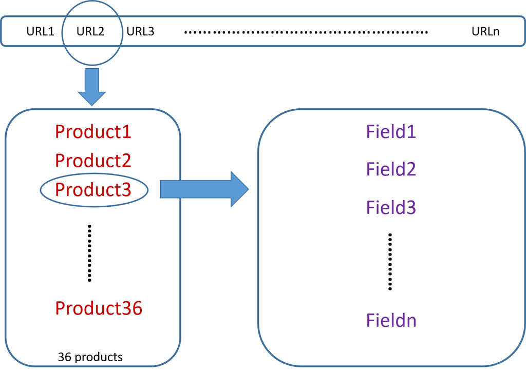

## Getting Data Using Scrapy

Variables of CPU data:

```
##  [1] "core"        "name"        "power"       "rating"      "url"
##  [6] "series"      "brand"       "corename"    "rank"        "productname"
## [11] "l3cache"     "l2cache"     "freq"        "price"       "socket"
```

Variables of GPU data:

```
##  [1] "rating"          "chipmake"        "brand"
##  [4] "memorysize"      "rank"            "coreclock"
##  [7] "url"             "memorytype"      "memoryinterface"
## [10] "gpu"             "productname"     "price"
```

Data are cleaned using R

## Exploratory Analysis

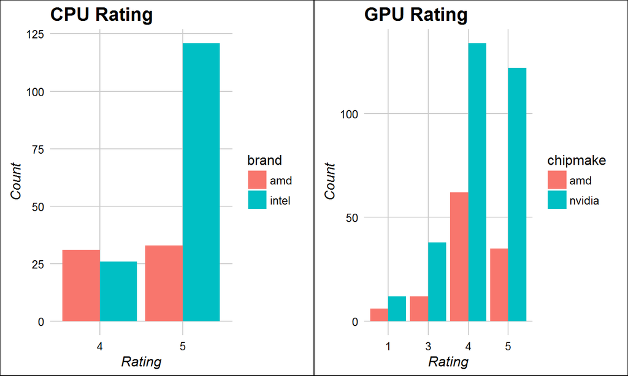

## Exploratory Analysis

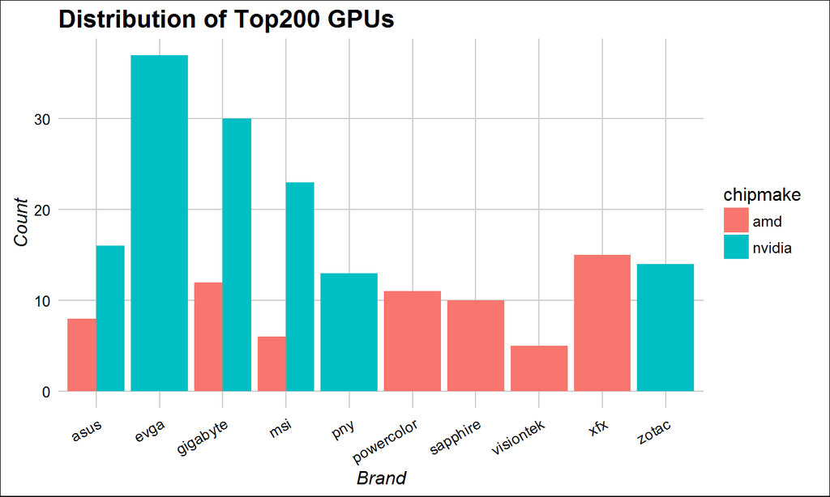

## Exploratory Analysis

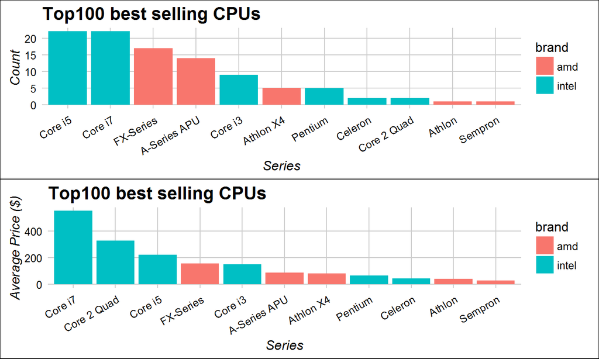

## Exploratory Analysis

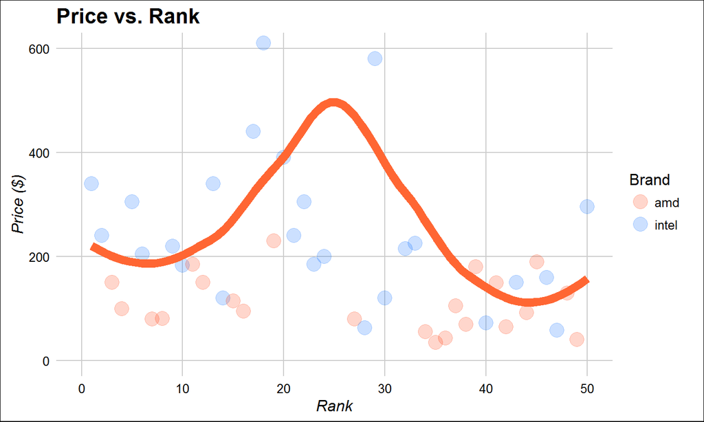

## Exploratory Analysis

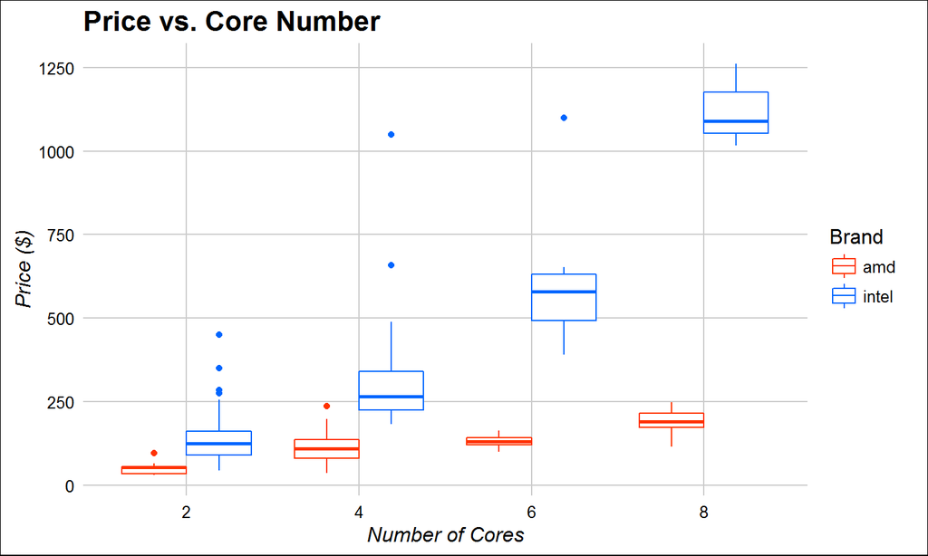

## Exploratory Statistical Analysis

```r
data6 <- cpu %>% top_n(-211, rank) %>%
    select(brand, series, core, power, freq, price)
price_amd <- data6$price[data6$brand == 'amd']
price_intel <- data6$price[data6$brand == 'intel']
t.test(price_intel, price_amd,
       alternative = "greater", paired = FALSE,
       var.equal = FALSE, conf.level = 0.95)
```

```
##
##  Welch Two Sample t-test
##
## data:  price_intel and price_amd
## t = 6.8855, df = 175.72, p-value = 4.913e-11
## alternative hypothesis: true difference in means is greater than 0
## 95 percent confidence interval:
##  121.9726      Inf
## sample estimates:
## mean of x mean of y
##  279.5171  118.9942
```

## Exploratory Statistical Analysis

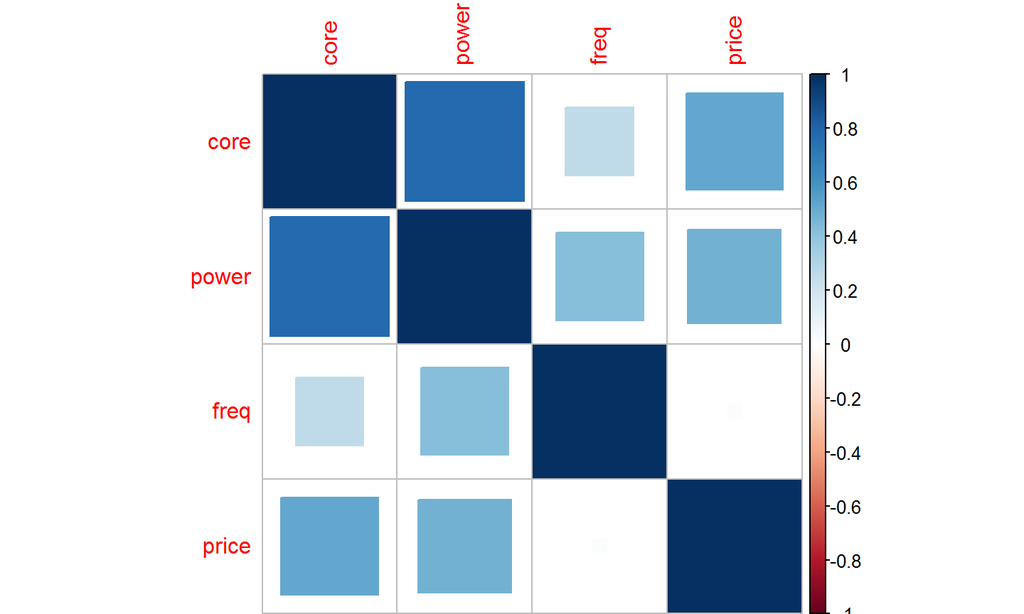

## Exploratory Statistical Analysis

Use linear regression to predict the price CPU.  
**Predictor**: brand, series, core, power, freq.  
**Response**: price.

```r
model_empty = lm(price ~ 1, data = data6)
model_full = lm(price ~ ., data = data6)
scope = list(lower = formula(model_empty),
             upper = formula(model_full))
AICmodel_back = step(model_full, scope,
                     direction = "backward", k = 2)
AICmodel_forward = step(model_empty, scope,
                        direction = "forward", k = 2)
```

## Exploratory Statistical Analysis

```r
summary(AICmodel_back)
```

lm(formula = price ~ series + core + power, data = data6)

Residual standard error: 123.5 on 192 degrees of freedom  
Multiple R-squared: 0.7529, Adjusted R-squared: 0.7298  
F-statistic: 32.51 on 18 and 192 DF, p-value: < 2.2e-16

## Exploratory Statistical Analysis

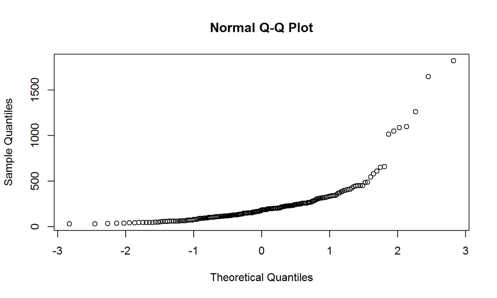

```r
qqnorm(data6$price)
```

## Exploratory Statistical Analysis

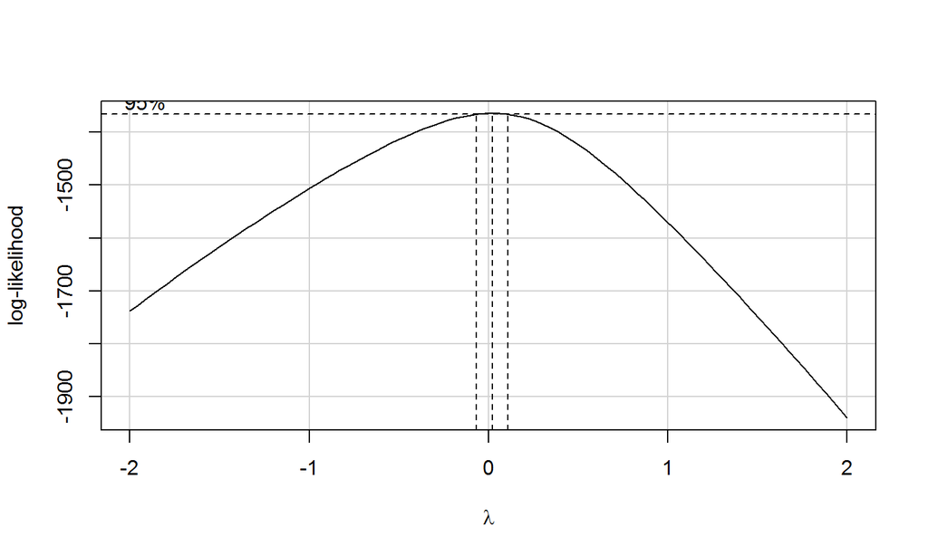

```r
boxCox(AICmodel_back)
```

## Exploratory Statistical Analysis

Regression after BoxCox transformation

```r
model_bc <- lm(log(price) ~ series + core + power, data = data6)
summary(model_bc)
```

lm(formula = log(price) ~ series + core + power, data = data6)

Residual standard error: 0.2751 on 192 degrees of freedom  
Multiple R-squared: 0.8821, Adjusted R-squared: 0.871  
F-statistic: 79.79 on 18 and 192 DF, p-value: < 2.2e-16

## Conclusion

- From the analysis, we can see:
  - To my suprise, the price of CPUs showed weak correlation with the operating frequency.
  - Although AMD has a wide range of product line, it is dominated by Intel and Nvidia in CPU and GPU area, respectively.
- If I had more time, I will:
  - Build a interactive app to allow others to explore the data set.
  - Scrape more features from the web, like product release date.
  - Apply machine learning algorithms to predict the user rating of a product based on its information.